# Project 4 - text classification

Jawaid Hakim

2022-11-09

# 1 Introduction

In this markdown we will use [tidymodels](https://www.tidymodels.org) to build ham/spam classifiers for email messages. The library provides a framework for modeling and machine learning using [tidyverse](https://www.tidyverse.org) principles.

# 2 Load library

```r
library(tidyverse)
library(tidymodels)
library(parsnip)
library(textrecipes)
library(readtext)
```

```r
set.seed(1234)
```

Let’s detect the number of available cores. We use this during model setup.

```r
detected_cores <- parallel::detectCores(logical = TRUE)
usable_cores = 1 + (detected_cores / 2)
usable_cores
```

```
## [1] 5
```

On Unix and Mac we can leverage multiple CPU/core. Comment out on Windows.

```r
library(doMC)
registerDoMC(cores = usable_cores)
```

# 3 Load data

Email data is too big to load from [Github](https://github.com/himalayahall/DATA607/blob/main/Project4/EMAILSpamCollectionFull.csv). Download into current working directory.

```r
df <- read.csv("./EMAILSpamCollectionFull.csv")
```

Strip HTML tags and convert category into factor.

```r
df <- df %>%
    filter(text != "") %>%
    mutate(text = str_replace_all(text, "<.*?>", "")) %>% # strip HTML tags
    mutate(text = str_trim(text, "both")) %>%
    mutate(category = factor(category, levels = c('spam', 'ham'))) %>% # order is important - spam first
    mutate(n_words = tokenizers::count_words(text))

glimpse(df)
```

```
## Rows: 7,953
## Columns: 6
## $ id       <int> 1, 2, 3, 4, 5, 6, 7, 8, 9, 10, 11, 12, 13, 14, 15, 16, 17, 18…
## $ from     <chr> "robert elz <kre@munnari.oz.au>", "steve burt <steve_burt@cur…
## $ subject  <chr> "re: new sequences window", "[zzzzteana] re: alexander", "[zz…
## $ category <fct> ham, ham, ham, ham, ham, ham, ham, ham, ham, ham, ham, ham, h…
## $ text     <chr> "Date:        Wed, 21 Aug 2002 10:54:46 -0500    From:       …
## $ n_words  <int> 227, 115, 241, 168, 204, 147, 104, 42, 165, 33, 163, 107, 65,…
```

We expect data sets to be unbalanced, i.e. number of spam observations is a minority class. This class imbalance will influence how we build ML models.

```r
props <- df %>%
  count(category) %>%
  mutate(prop = n/sum(n))
props
```

```
##   category    n      prop
## 1     spam 2400 0.3017729
## 2      ham 5553 0.6982271
```

## 3.1 Data split

Split into train and test data sets. Test data will be set aside and not used until the final model is tested.

```r
data_split <- initial_split(df, strata = category)
data_train <- training(data_split)
data_test <- testing(data_split)
```

Verify train/test splits have same proportions as original data set. Check.

```r
# training set proportions by category
data_train %>%
  count(category) %>%
  mutate(prop = n/sum(n))
```

```
##   category    n      prop
## 1     spam 1800 0.3018109
## 2      ham 4164 0.6981891
```

```r
# test set proportions by category
data_test  %>%
  count(category) %>%
  mutate(prop = n/sum(n))
```

```
##   category    n      prop
## 1     spam  600 0.3016591
## 2      ham 1389 0.6983409
```

## 3.2 Resampling

To evaluate model performance during during model selection we **may** use 10-fold Cross-Validation. I say **may** use 10-fold because some models, like Randomforest, do not require it to get an unbiased estimate of the test set error (it is estimated internally),

Let’s define the folds and make sure folds have same strata as original data.

```r
data_folds <- vfold_cv(data_train, strata = category) # defaults to 10 fold, 1 repeats
data_folds
```

```
## #  10-fold cross-validation using stratification
## # A tibble: 10 × 2
##    splits             id
##    <list>             <chr>
##  1 <split [5367/597]> Fold01
##  2 <split [5367/597]> Fold02
##  3 <split [5367/597]> Fold03
##  4 <split [5367/597]> Fold04
##  5 <split [5368/596]> Fold05
##  6 <split [5368/596]> Fold06
##  7 <split [5368/596]> Fold07
##  8 <split [5368/596]> Fold08
##  9 <split [5368/596]> Fold09
## 10 <split [5368/596]> Fold10
```

## 3.3 Recipe

Set up model recipe to predict **category** (outcome) from the following predictors - email **subject**, sender email address (**from**), and the email **text**.

Knowing that we have a large quantity of data but the data is unbalanced, we downsample such that the majority class level will have (at most) twice as many rows as the minority level.

Token transformations are done via [textrecipes] (https://www.rdocumentation.org/packages/textrecipes/versions/1.0.10)

Most models work with numeric data, not text. Text data is typically converted into a numeric representation before it can be used to build models. There are a number of techniques for encoding text such as [Tf-idf](https://en.wikipedia.org/wiki/Tf%E2%80%93idf) and [word embedding](https://www.tensorflow.org/text/guide/word_embeddings). Both techniques can be used with tidymodels.

Load Stanford GloVE(https://nlp.stanford.edu/pubs/glove.pdf) trained on words from a 6 billion token corpus.

```r
glove6b <- textdata::embedding_glove6b(dimensions = 100)
glove6b
```

```
## # A tibble: 400,000 × 101
##    token      d1      d2      d3      d4      d5      d6      d7      d8      d9
##    <chr>   <dbl>   <dbl>   <dbl>   <dbl>   <dbl>   <dbl>   <dbl>   <dbl>   <dbl>
##  1 "the" -0.0382 -0.245   0.728  -0.400   0.0832  0.0440 -0.391   0.334  -0.575
##  2 ","   -0.108   0.111   0.598  -0.544   0.674   0.107   0.0389  0.355   0.0635
##  3 "."   -0.340   0.209   0.463  -0.648  -0.384   0.0380  0.171   0.160   0.466
##  4 "of"  -0.153  -0.243   0.898   0.170   0.535   0.488  -0.588  -0.180  -1.36
##  5 "to"  -0.190   0.0500  0.191  -0.0492 -0.0897  0.210  -0.550   0.0984 -0.201
##  6 "and" -0.0720  0.231   0.0237 -0.506   0.339   0.196  -0.329   0.184  -0.181
##  7 "in"   0.0857 -0.222   0.166   0.134   0.382   0.354   0.0129  0.225  -0.438
##  8 "a"   -0.271   0.0440 -0.0203 -0.174   0.644   0.712   0.355   0.471  -0.296
##  9 "\""  -0.305  -0.236   0.176  -0.729  -0.283  -0.256   0.266   0.0253 -0.0748
## 10 "'s"   0.589  -0.202   0.735  -0.683  -0.197  -0.180  -0.392   0.342  -0.606
## # … with 399,990 more rows, and 91 more variables: d10 <dbl>, d11 <dbl>,
## #   d12 <dbl>, d13 <dbl>, d14 <dbl>, d15 <dbl>, d16 <dbl>, d17 <dbl>,
## #   d18 <dbl>, d19 <dbl>, d20 <dbl>, d21 <dbl>, d22 <dbl>, d23 <dbl>,
## #   d24 <dbl>, d25 <dbl>, d26 <dbl>, d27 <dbl>, d28 <dbl>, d29 <dbl>,
## #   d30 <dbl>, d31 <dbl>, d32 <dbl>, d33 <dbl>, d34 <dbl>, d35 <dbl>,
## #   d36 <dbl>, d37 <dbl>, d38 <dbl>, d39 <dbl>, d40 <dbl>, d41 <dbl>,
## #   d42 <dbl>, d43 <dbl>, d44 <dbl>, d45 <dbl>, d46 <dbl>, d47 <dbl>, …
```

```r
glove6b %>% filter(token == 'hello')
```

```
## # A tibble: 1 × 101
##   token    d1    d2    d3     d4     d5    d6    d7    d8      d9     d10   d11
##   <chr> <dbl> <dbl> <dbl>  <dbl>  <dbl> <dbl> <dbl> <dbl>   <dbl>   <dbl> <dbl>
## 1 hello 0.267 0.396 0.617 -0.775 -0.104 0.267 0.279 0.310 0.00547 -0.0853 0.736
## # … with 89 more variables: d12 <dbl>, d13 <dbl>, d14 <dbl>, d15 <dbl>,
## #   d16 <dbl>, d17 <dbl>, d18 <dbl>, d19 <dbl>, d20 <dbl>, d21 <dbl>,
## #   d22 <dbl>, d23 <dbl>, d24 <dbl>, d25 <dbl>, d26 <dbl>, d27 <dbl>,
## #   d28 <dbl>, d29 <dbl>, d30 <dbl>, d31 <dbl>, d32 <dbl>, d33 <dbl>,
## #   d34 <dbl>, d35 <dbl>, d36 <dbl>, d37 <dbl>, d38 <dbl>, d39 <dbl>,
## #   d40 <dbl>, d41 <dbl>, d42 <dbl>, d43 <dbl>, d44 <dbl>, d45 <dbl>,
## #   d46 <dbl>, d47 <dbl>, d48 <dbl>, d49 <dbl>, d50 <dbl>, d51 <dbl>, …
```

We will use word embedding in the data recipe pipeline to encode predictor variables.

```r
library(themis) # for step_downsample
data_recipe <- recipe(category ~ ., data = data_train)
data_recipe <- data_recipe %>%
                # retain these variables for reference (not to be used as model outcome or predictors)
                update_role(id, n_words, new_role = "REF") %>%
                step_tokenize(all_predictors(),
                                options = list(lowercase = TRUE,
                                strip_punct = TRUE)) %>%

                # set max tokens (words) for each predictor
                step_tokenfilter(all_predictors(), max_tokens = 200) %>%

                # remove stopwords (optional)
                step_stopwords(text) %>%
                step_stopwords(subject) %>%

                # stemming (optional)
                step_stem(text) %>%
                step_stem(subject) %>%

                # merge from and subject (optional)
                step_tokenmerge(from, subject) %>%

                # GloVE word embedding
                step_word_embeddings(all_predictors(), embeddings = glove6b) %>%

                # tf-idf encoding is iyet another option
                # step_tfidf(all_predictors()) %>% #TF-IDF word embedding

                step_downsample(category,
                                under_ratio = 2
                                )
data_recipe
```

```
## Recipe
##
## Inputs:
##
##       role #variables
##    outcome          1
##  predictor          3
##        REF          2
##
## Operations:
##
## Tokenization for all_predictors()
## Text filtering for all_predictors()
## Stop word removal for text
## Stop word removal for subject
## Stemming for text
## Stemming for subject
## Merging tokens for from, subject
## Word embeddings aggregated from all_predictors()
## Down-sampling based on category
```

Set up metrics of interest.

```r
metrics = metric_set(accuracy, roc_auc, pr_auc, precision, recall)
metrics
```

```
## # A tibble: 5 × 3
##   metric    class        direction
##   <chr>     <chr>        <chr>
## 1 accuracy  class_metric maximize
## 2 roc_auc   prob_metric  maximize
## 3 pr_auc    prob_metric  maximize
## 4 precision class_metric maximize
## 5 recall    class_metric maximize
```

Set up re-sampling control.

```r
control <- control_resamples(save_pred = TRUE, allow_par = TRUE, parallel_over = "resamples")
control
```

```
## grid/resamples control object
```

## 3.4 Null model

It’s important to look at the **null model** to set up a baseline. For binary classification modeling, the null model always predicts the majority class. Consequently, **accuracy** of null model equals proportion of the majority class. For example, if there are 90% ham (not spam) observations then accuracy of the null model will also be 90%. Another way to look at it is that a model that is 90% accurate is not necessarily any good!

```r
null_classification <- null_model() %>%
  set_engine("parsnip") %>%
  set_mode("classification")

null_rs <- workflow() %>%
  add_recipe(data_recipe) %>%
  add_model(null_classification) %>%
  fit_resamples(
    data_folds,
    metrics = metrics,
    control = control
  )
```

We can see the null model has Accuracy equal to proportion of the majority class and a very low [ROC](https://developers.google.com/machine-learning/crash-course/classification/roc-and-auc). Slope of the ROC curve shows the null model is unable to discriminate between the two classes.

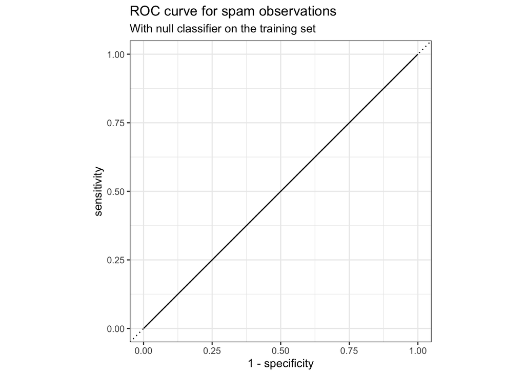

```r
null_predictions <- collect_predictions(null_rs)
null_predictions  %>%
  roc_curve(truth = category, .pred_spam) %>%
  autoplot() +
  labs(
    color = NULL,
    title = "ROC curve for spam observations",
    subtitle = "With null classifier on the training set"
  )
```

```r
null_rs %>%
  collect_metrics()
```

```
## # A tibble: 5 × 6
##   .metric   .estimator    mean     n    std_err .config
##   <chr>     <chr>        <dbl> <int>      <dbl> <chr>
## 1 accuracy  binary       0.698    10  0.0000826 Preprocessor1_Model1
## 2 pr_auc    binary       0.651    10  0.0000413 Preprocessor1_Model1
## 3 precision binary     NaN         0 NA         Preprocessor1_Model1
## 4 recall    binary       0        10  0         Preprocessor1_Model1
## 5 roc_auc   binary       0.5      10  0         Preprocessor1_Model1
```

The [confusion matrix](https://www.sciencedirect.com/topics/engineering/confusion-matrix) confirms that the null model simply guesses the majority class *ham* for each prediction.

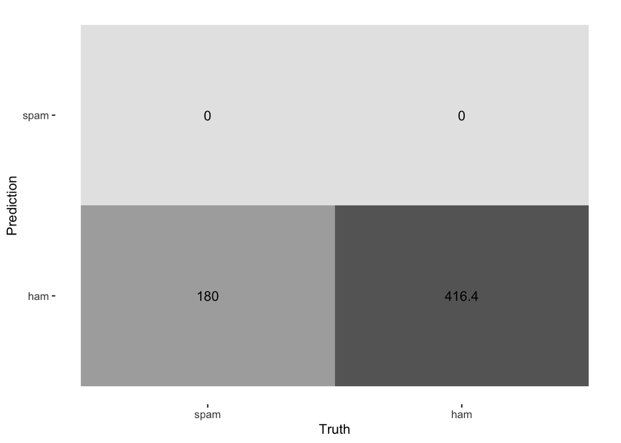

```r
conf_mat_resampled(null_rs, tidy = FALSE) %>%
  autoplot(type = "heatmap")
```

## 3.5 Model setup

The [tidymodels](https://tidymodels.tidymodels.org) framework makes it easy to plug-and-play with models. Below are some models that we can use - un-comment to select.

```r
# Randomforest
# https://cran.r-project.org/web/packages/ranger/ranger.pdf
model <- rand_forest() %>%
  set_mode("classification") %>%
  set_engine(engine = "ranger", importance = "impurity")

#Linear support vector machine.
# model <- svm_linear() %>%
#   set_mode("classification") %>%
#   set_engine(engine = "kernlab")

# Boosted trees.
# model <- boost_tree() %>%
#   set_mode("classification") %>%
#   set_engine(engine = "xgboost", trees = 20)
# model

# Linear support vector machine.
# model <- svm_linear() %>%
#   set_mode("classification") %>%
#   set_engine(engine = "kernlab")
# model

# Multi-layer perceptron, a single layer neural network.
# num_epochs = 20
# model <- mlp(hidden_units = 128, dropout = 0.1, epochs = num_epochs) %>%
#   set_mode("classification") %>%
#   # Also set engine-specific `verbose` argument to prevent logging the results:
#   set_engine("keras", verbose = 1)

model
```

```
## Random Forest Model Specification (classification)
##
## Engine-Specific Arguments:
##   importance = impurity
##
## Computational engine: ranger
```

## 3.6 Workflow setup

Create [workflow](https://workflows.tidymodels.org) to wrap data recipe and model.

```r
data_wf <- workflow() %>%
                add_recipe(data_recipe) %>%
                add_model(model)
data_wf
```

```
## ══ Workflow ════════════════════════════════════════════════════════════════════
## Preprocessor: Recipe
## Model: rand_forest()
##
## ── Preprocessor ────────────────────────────────────────────────────────────────
## 9 Recipe Steps
##
## • step_tokenize()
## • step_tokenfilter()
## • step_stopwords()
## • step_stopwords()
## • step_stem()
## • step_stem()
## • step_tokenmerge()
## • step_word_embeddings()
## • step_downsample()
##
## ── Model ───────────────────────────────────────────────────────────────────────
## Random Forest Model Specification (classification)
##
## Engine-Specific Arguments:
##   importance = impurity
##
## Computational engine: ranger
```

## 3.7 Model training

Train the model using Cross-Validation, record desired metrics, save predictions.

> In random forests, there is no need for cross-validation or a separate test set to get an unbiased estimate of the test set error. It is estimated internally, during the run.

```r
model_cls <- class(model)
if (model_cls[1] != "rand_forest") {
    nb_rs <- fit_resamples(
        data_wf,
        data_folds,
        metrics = metrics,
        control = control
    )
    nb_rs_metrics <- collect_metrics(nb_rs)
    print(nb_rs_metrics)
}
```

## 3.8 Model evaluation

```r
if (model_cls[1] != "rand_forest") {
    nb_rs_metrics <- collect_metrics(nb_rs)
    nb_rs_metrics
}
```

```r
if (model_cls[1] != "rand_forest") {
    nb_rs_predictions <- collect_predictions(nb_rs)
    nb_rs_predictions %>%
      group_by(id) %>%
      roc_curve(truth = category, .pred_spam) %>%
      autoplot() +
      labs(
        color = NULL,
        title = "ROC curve for spam observations",
        subtitle = "Each resample fold is shown in a different color"
      )
}
```

```r
if (model_cls[1] != "rand_forest") {
    conf_mat_resampled(nb_rs, tidy = FALSE) %>%
    autoplot(type = "heatmap")
}
```

## 3.9 Final model

So far we have been using the training data to both train and evaluate the model (using cross-validation). We can expect that the model **will not** perform quite as well on unseen data.

So far we have been keeping the test split in our back pocket. Now it’s time to use the precious test data to evaluate the final model. Do final fit - train with full training data and test with testing data.

```r
final_fitted <- last_fit(data_wf, data_split, metrics = metrics)
final_fitted
```

```
## # Resampling results
## # Manual resampling
## # A tibble: 1 × 6
##   splits              id               .metrics .notes   .predictions .workflow
##   <list>              <chr>            <list>   <list>   <list>       <list>
## 1 <split [5964/1989]> train/test split <tibble> <tibble> <tibble>     <workflow>
```

Extract predictions and metrics. The model has performed extremely well acrss all metrics.

```r
final_predictions <- collect_predictions(final_fitted)
final_metrics <- collect_metrics(final_fitted)
final_metrics
```

```
## # A tibble: 5 × 4
##   .metric   .estimator .estimate .config
##   <chr>     <chr>          <dbl> <chr>
## 1 accuracy  binary         0.971 Preprocessor1_Model1
## 2 precision binary         0.953 Preprocessor1_Model1
## 3 recall    binary         0.95  Preprocessor1_Model1
## 4 roc_auc   binary         0.992 Preprocessor1_Model1
## 5 pr_auc    binary         0.982 Preprocessor1_Model1
```

The confusion matrix confirms the model is performing well.

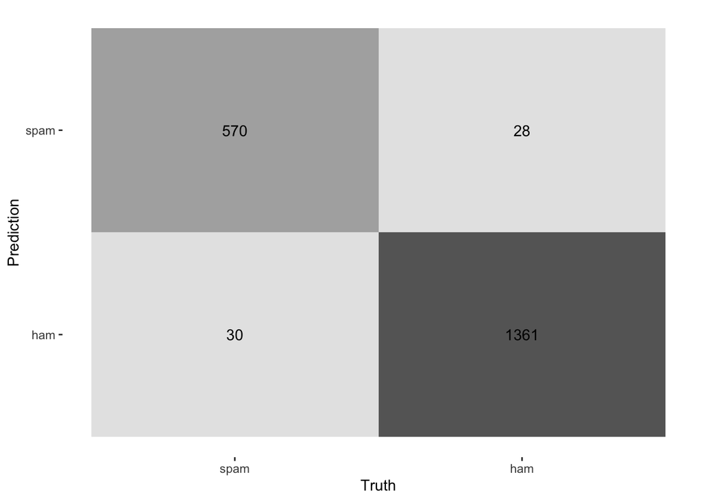

```r
final_predictions %>%
  conf_mat(truth = category, estimate = .pred_class) %>%
  autoplot(type = "heatmap")
```

Plot final model’s ROC curve.

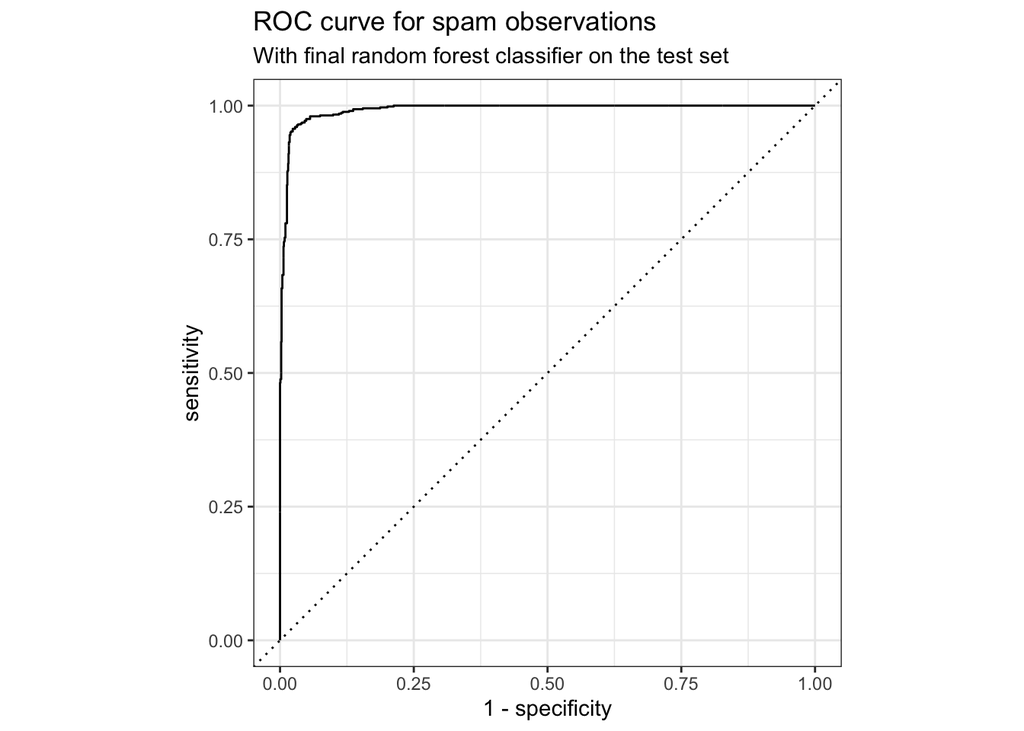

```r
final_predictions  %>%
  roc_curve(truth = category, .pred_spam) %>%
  autoplot() +
  labs(
    color = NULL,
    title = "ROC curve for spam observations",
    subtitle = "With final random forest classifier on the test set"
  )
```